# NYPD_week_3

2023-03-01

## **Project Description**

The project will import NYC shooting data from (https://catalog.data.gov/dataset?q=NYPD+Shooting+Incident+Data+%28Historic%29) and analyze it. The data breaks down shooting victims and perpetrators by borough, race, sex, age, location, and indicates whether or not the shooting was a murder.

1. What are the murdered victims by race? Sex? Age?
2. In what borough are the most murdered victims?

In this analysis, I will group the data by murdered victims by borough, race, sex, and age.

```r
library(tidyverse)
library(lubridate)
```

## **Importing Data** (Step 1)

```r
data_in <- read_csv("NYPD_Shooting_Incident_Data__Historic_.csv")
colnames(data_in)
```

```
##  [1] "INCIDENT_KEY"            "OCCUR_DATE"
##  [3] "OCCUR_TIME"              "BORO"
##  [5] "PRECINCT"                "JURISDICTION_CODE"
##  [7] "LOCATION_DESC"           "STATISTICAL_MURDER_FLAG"
##  [9] "PERP_AGE_GROUP"          "PERP_SEX"
## [11] "PERP_RACE"               "VIC_AGE_GROUP"
## [13] "VIC_SEX"                 "VIC_RACE"
## [15] "X_COORD_CD"              "Y_COORD_CD"
## [17] "Latitude"                "Longitude"
## [19] "Lon_Lat"
```

```r
summary(data_in)
```

```
##   INCIDENT_KEY        OCCUR_DATE         OCCUR_TIME           BORO
##  Min.   :  9953245   Length:25596       Length:25596      Length:25596
##  1st Qu.: 61593633   Class :character   Class1:hms        Class :character
##  Median : 86437258   Mode  :character   Class2:difftime   Mode  :character
##  Mean   :112382648                      Mode  :numeric
##  3rd Qu.:166660833
##  Max.   :238490103
##
##     PRECINCT      JURISDICTION_CODE LOCATION_DESC      STATISTICAL_MURDER_FLAG
##  Min.   :  1.00   Min.   :0.0000    Length:25596       Mode :logical
##  1st Qu.: 44.00   1st Qu.:0.0000    Class :character   FALSE:20668
##  Median : 69.00   Median :0.0000    Mode  :character   TRUE :4928
##  Mean   : 65.87   Mean   :0.3316
##  3rd Qu.: 81.00   3rd Qu.:0.0000
##  Max.   :123.00   Max.   :2.0000
##                   NA's   :2
##  PERP_AGE_GROUP       PERP_SEX          PERP_RACE         VIC_AGE_GROUP
##  Length:25596       Length:25596       Length:25596       Length:25596
##  Class :character   Class :character   Class :character   Class :character
##  Mode  :character   Mode  :character   Mode  :character   Mode  :character
##
##
##
##
##    VIC_SEX            VIC_RACE           X_COORD_CD        Y_COORD_CD
##  Length:25596       Length:25596       Min.   : 914928   Min.   :125757
##  Class :character   Class :character   1st Qu.:1000011   1st Qu.:182782
##  Mode  :character   Mode  :character   Median :1007715   Median :194038
##                                        Mean   :1009455   Mean   :207894
##                                        3rd Qu.:1016838   3rd Qu.:239429
##                                        Max.   :1066815   Max.   :271128
##
##     Latitude       Longitude        Lon_Lat
##  Min.   :40.51   Min.   :-74.25   Length:25596
##  1st Qu.:40.67   1st Qu.:-73.94   Class :character
##  Median :40.70   Median :-73.92   Mode  :character
##  Mean   :40.74   Mean   :-73.91
##  3rd Qu.:40.82   3rd Qu.:-73.88
##  Max.   :40.91   Max.   :-73.70
##
```

## **Tidy up, Transform, and Handle the Missing Data** (Step 2)

We observe that there are some missing values for variables LOCATION_DESC, PERP_AGE_GROUP, PERP_SEX, and PERP_RACE. Since it does not make sense to assume values for those missing variables, we will remove them entirely. Another justification for not considering the specified variables is that, for this project, we are interested solely in the statistics about victims and where shooting incidents were more prevalent in the city. For that reason, we are also not interested in variables INCIDENT_KEY, OCCUR_TIME, JURISDICTION_CODE, PRECINCT, X_COORD_CD, Y_COORD_CD, Latitude, Longitude, and Lon_Lat. This transforms the data frame. We will also convert OCCUR_DATE to a date object from a character string and finally show a summary of the data.

```r
data_in <- data_in %>% select(-c(INCIDENT_KEY, OCCUR_TIME, JURISDICTION_CODE, PRECINCT, LOCATION_DESC, PERP_AGE_GROUP, PERP_SEX, PERP_RACE, X_COORD_CD, Y_COORD_CD, Latitude, Longitude, Lon_Lat)) %>% mutate(OCCUR_DATE=mdy(OCCUR_DATE))
summary(data_in)
```

```
##    OCCUR_DATE             BORO           STATISTICAL_MURDER_FLAG
##  Min.   :2006-01-01   Length:25596       Mode :logical
##  1st Qu.:2009-05-10   Class :character   FALSE:20668
##  Median :2012-08-26   Mode  :character   TRUE :4928
##  Mean   :2013-06-13
##  3rd Qu.:2017-07-01
##  Max.   :2021-12-31
##  VIC_AGE_GROUP        VIC_SEX            VIC_RACE
##  Length:25596       Length:25596       Length:25596
##  Class :character   Class :character   Class :character
##  Mode  :character   Mode  :character   Mode  :character
##
##
##
```

## **Analyze the Data** (Step 3a)

We will perform two different analyses of the data. 1) We want to know the murder counts by borough. We will group the data by BORO and summarize the murder counts. 2) We are also interested in the murdered vicitms by race in the city as a whole.

```r
murders_by_borough <- data_in %>% group_by(BORO) %>% summarise(TOTAL_MURDERS = sum(STATISTICAL_MURDER_FLAG == TRUE))
victims_by_race <- data_in %>% group_by(VIC_RACE) %>% summarise(TOTAL_MURDERS = sum(STATISTICAL_MURDER_FLAG == TRUE))
victims_by_age <- data_in %>% group_by(VIC_AGE_GROUP) %>% summarise(TOTAL_MURDERS = sum(STATISTICAL_MURDER_FLAG == TRUE))
victims_by_sex <- data_in %>% group_by(VIC_SEX) %>% summarise(TOTAL_MURDERS = sum(STATISTICAL_MURDER_FLAG == TRUE))
```

## **Visualize the Data** (Step 3b)

We want to visualize both the total murders by borough as well as the murder counts by race using bar graphs.

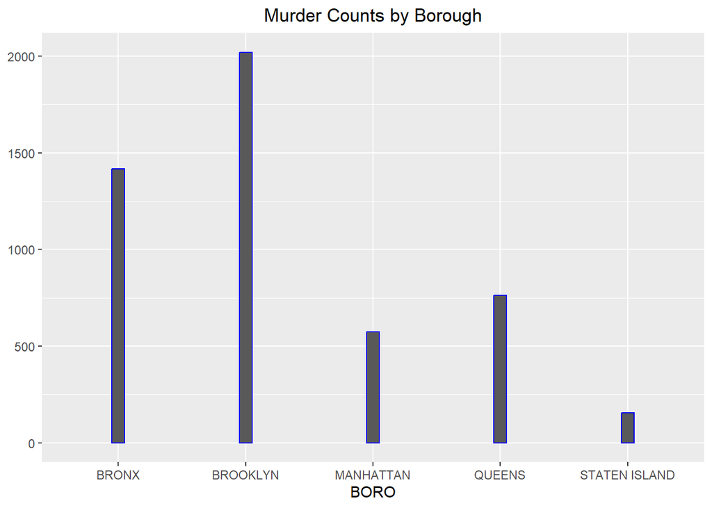

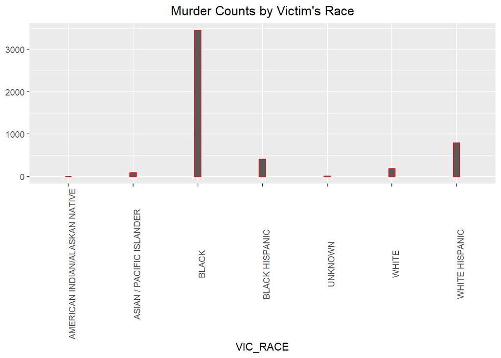

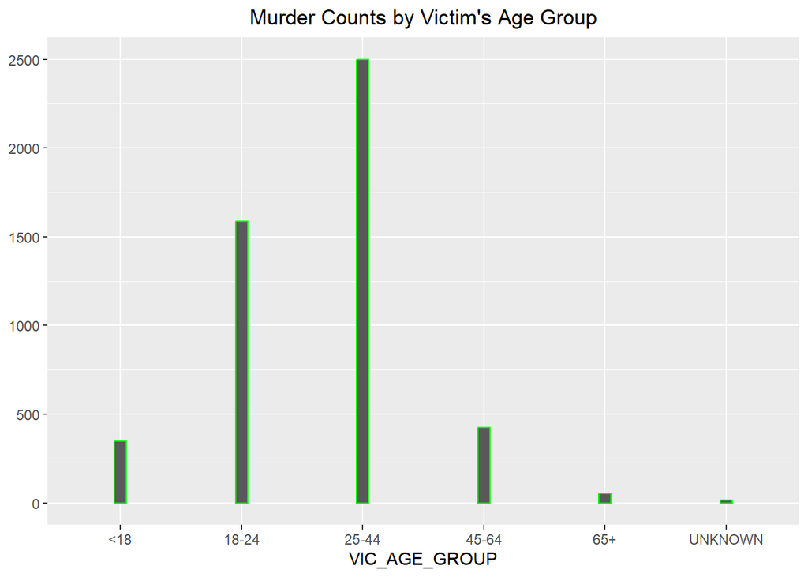

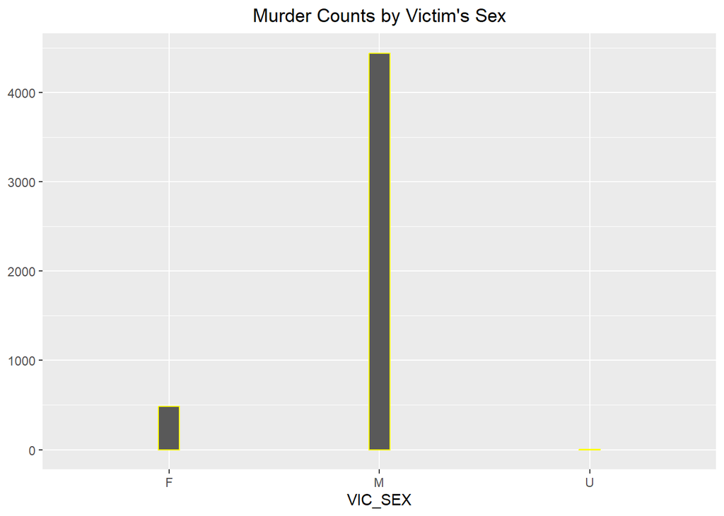

The data has determined that the most murders by borough occurred in Brooklyn, with the most murdered victims by race being black, by sex being male, and by age group between 25-44. Though no assumptions about the data should be made at this point, it can lead to the posing of questions such as: why are there so many murdered victims in Brooklyn? Is it solely due to population, or are there other reasons? Another potential question to be investigated is why are most of the murdered victims black, and how that can change based on the borough.

## **Bias Identification and Elimination** (Step 4)

In conclusion, it was determined that the most murders by borough occurred in Brooklyn, and the most murdered victims were Black by race, male by sex, and 25-44 by age. By removing the variables PERP_AGE_GROUP, PERP_SEX, and PERP_RACE instead of filling in arbitrary values for the missing values in those columns, we have eliminated sources of bias about what groups of people have been carrying out the shootings. I assumed that the most populated borough would have the most murders, which turned out to be the case with Brooklyn. However, it cannot be assumed that Brooklyn has the most cases solely because of population, and more investigation is needed.